# Métodos Computacionais II

2018/2

[Jony Arrais Pinto Junior](http://lattes.cnpq.br/4940428746026448)

## 1 - Conteúdo Aula 06

- Loopings e condicionamentos;
- Criando funções;
- Distribuições de probabilidade.

## 2 - Condicionamento

Em certas ocasiões, queremos ou precisamos executar parte do código apenas se alguma determinada condição for atendida. O R fornece algumas opções básicas para estruturar seu código: **if(…)**, **if(…) else** e **ifelse(…)**. A seguir, vamos discutir cada uma das três opções.

### 2.1 - O if(…)

A estrutura básica do if(…) é a seguinte:

```r
if(condicao){

  # conjunto de comandos que serão executados
  # caso a condição seja TRUE

}
```

- Notem que, o início do código se dá com o comando if seguido de parênteses e chaves;
- Dentro do parênteses é preciso conter uma condição lógica, que deverá ter como resultado ou TRUE ou FALSE;
- Dentro das chaves temos um conjunto de comandos que serão executado se a condição do parênteses for TRUE.

Veja o exemplo abaixo:

```r
# Criando o objeto x
x = 10


# só executa se a condição lógica for atendida
if(x < 20){
  y = 1
}

# note que x foi criado
exists("x")
```

```
## [1] TRUE
```

```r
x
```

```
## [1] 10
```

```r
# só executa se a condição lógica for atendida
if(x > 20){
  z = 10
}

# note que z não foi criado
exists("z")
```

```
## [1] FALSE
```

### 2.2 - O if(…) else

Vamos ver agora como acrescentar ao if(…) o opcional else.

A estrutura básica do if(…) else é a apresentada a seguir:

```r
if(condicao){

  # conjunto de comandos que serão executados
  # caso a condição seja TRUE

} else{

  # conjunto de comandos que serão executados
  # caso a condição seja FALSE

}
```

- Percebam que o início do código se dá do mesmo modo que no caso anterior, com o comando if seguido de parênteses e chaves;
- Novamente, dentro do parênteses é preciso conter uma condição lógica, que deverá ter como resultado ou TRUE ou FALSE;
- Dentro das chaves do if(…) temos um conjunto de comandos que serão executado se a condição do parênteses for TRUE;
- Logo em seguida temos a presença do opcional else, seguido de chaves;
- Dentro das chaves do else temos um conjunto de comandos que serão executado se a condição do parênteses for FALSE.

```r
# Criando o objeto x
x = 10



if(x < 20){
  y = 1
  cat("O número y criado é igual a", y)
} else{
  y = 10
  cat("O número y criado é igual a", y)
}
```

```
## O número y criado é igual a 1
```

É possível encadear diversos if(…) else em sequência como mostra o exemplo a seguir:

```r
# Criando o objeto x
x = 10

if(x < 10){
  y = 1
  cat("O número y criado é igual a", y)
} else if(x >=10 & x<20){
  y = 10
  cat("O número y criado é igual a", y)
} else{
    y = 100
  cat("O número y criado é igual a", y)
}
```

```
## O número y criado é igual a 10
```

Se x for um vetor ao invés de um número, será que o conjunto de comandos criados anteriormente serão executados para todos os componentes de x?

```r
# Criando o objeto x
x = c(310,20,230,40)

if(x < 10){
  y = 1
  cat("O número y criado é igual a", y)
} else if(x >=10 & x<20){
  y = 10
  cat("O número y criado é igual a", y)
} else{
    y = 100
  cat("O número y criado é igual a", y)
}
```

```
## Warning in if (x < 10) {: a condição tem comprimento > 1 e somente o
## primeiro elemento será usado
```

```
## Warning in if (x >= 10 & x < 20) {: a condição tem comprimento > 1 e
## somente o primeiro elemento será usado
```

```
## O número y criado é igual a 100
```

### 2.2 - A função ifelse(…)

Os comandos if(…) e if(…) else não são vetorizados, como podemois perceber no exemplo criado na seção anterior. O conjunto de comandos executado, só levou em consideração o primeiro elementio do vetor x e exibiu uma mensagem de warning. Uma alternativa para estes casos, é utilizar a função ifelse(…).

A função ifelse(…) tem a seguinte estrutura básica:

```r
ifelse(conjunto_de_condicoes, valor_se_TRUE, valor_se_FALSE)
```

- Notem que, o primeiro argumento trata-se de um conjunto de condições (que podem ser aplicadas em um vetor), que retornará vários TRUE e FALSE;
- Já o segundo argumento trata-se do valor que será retornado quando o elemento do conjunto_de_condicoes for TRUE;
- E o terceiro argumento trata-se do valor que será retornado quando o elemento do conjunto_de_condicoes for FALSE.

```r
# Criando o objeto x
x = c(310,20,230,40)

ifelse(x >130, 1, 0)
```

```
## [1] 1 0 1 0
```

## 3 - Loopings

### 3.1 - O for(…)

Um looping que utiliza o for(…) no R tem a seguinte estrututa básica:

```r
for(j in conjunto_de_valores){
  # conjunto de comandos que
  # serão repetidos
  # tantas vezes quanto for o tamanho do conjunto de valores
}
```

- Notem que, o início do loop se dá, de forma bem similar ao if, com o comando for seguido de parênteses e chaves;
- Dentro do parênteses, temos um indicador que será usado durante o loop (no caso escolhemos o j para representar este indicador) e um conjunto de valores que será iterado (chamado aqui de conjunto_de_valores);
- Dentro das chaves, temos o conjunto de comandos que será executado durante o loop.

```r
x = 50
aux = 0

for(j in 1:10){
  aux = aux + x/j
}

aux
```

```
## [1] 146.4484
```

```r
for(j in 1:5){
  cat("Para cada iteração iremos apresentar o valor de:", x, "\n")
}
```

```
## Para cada iteração iremos apresentar o valor de: 50
## Para cada iteração iremos apresentar o valor de: 50
## Para cada iteração iremos apresentar o valor de: 50
## Para cada iteração iremos apresentar o valor de: 50
## Para cada iteração iremos apresentar o valor de: 50
```

### 3.2 - O while(…)

Um looping que utiliza o while(…) no R tem a seguinte estrututa básica:

```r
while(condicao_for_satisfeita){
  # conjunto de comandos que
  # serão repetidos
  # enquanto a condicao continuar retornando TRUE
}
```

- Notem que, o início do loop se dá com o comando while seguido de parênteses e chaves;
- Dentro do parênteses, temos uma condição que será verificada a cada iteração;
- Dentro das chaves, temos o conjunto de comandos que será executado enquanto a condição retornar TRUE.

```r
x = 1

while( x < 5){
  x = x + 1
  print(x)
}
```

```
## [1] 2
## [1] 3
## [1] 4
## [1] 5
```

```r
x = 1
while(x < 5){
  x = x+1
  if(x == 4){
    break
  }
  print(x)
}
```

```
## [1] 2
## [1] 3
```

## 4 - Criando funções no R

Uma das grandes vantagens de softwares estatísticos como o R é o facilidade em criar funções.

Uma função, pode ser vista, como uma sequência de passos que você deseja que o programa execute. Se você faz uso, rotineiramente, de uma sequência de passos, ao invés de ter que reescrever os passos todas as vezes, você pode simplesmente criar uma função.

Quando fazemos o uso de um pacote, na verdade estamos usando funções que outras pessoas já criaram.

Ao criar uma função é muito importante definir suas entradas (argumentos) e saídas (resultados a serem retornados).

Para criar uma função no R, precisamos utilizar a função function(…) que tem a seguinte estrutura básica:

```r
nome.funcao = function(argumentos){
  # conjunto de comandos que
  # serão realizados
}
```

Vamos supor que queiramos criar uma função que retorne a mensagem “Adoro Métodos Computacionais II” toda vez que for evocada:

```r
#Criando a função e chamando de mensagem

mensagem = function(){
  print("Adoro Métodos Computacionais II")
}

#evocando a função
mensagem()
```

```
## [1] "Adoro Métodos Computacionais II"
```

```r
#Criando uma função que soma dois números

soma.minha = function(x,y){
  valor = x + y
  return(valor)
}

soma.minha(2,4)
```

```
## [1] 6
```

O que acontece se ao invés de somarmos dois números, somarmos um número com uma letra?

```r
soma.minha(2,"h")
```

[output not shown]

```r
#Melhorando a função

soma.minha = function(x,y){
  if(class(x) != "numeric" | !is.numeric(y)){
    print("Você deve inserir dois números para que a função possa ser executada!")
  }else{
  valor = x + y
  return(valor)
  }
}

soma.minha(2,"h")
```

```
## [1] "Você deve inserir dois números para que a função possa ser executada!"
```

```r
soma.minha("h",2)
```

```
## [1] "Você deve inserir dois números para que a função possa ser executada!"
```

```r
soma.minha(2,4)
```

```
## [1] 6
```

Alguns argumentos já podem estar definidos a priori nas suas funções.

```r
potencia = function(x,base = 10){
 valor = base^x
 return(valor)
}

potencia(3)
```

```
## [1] 1000
```

```r
potencia(3,5)
```

```
## [1] 125
```

Crie uma função que calcula o valor de $f(y) = 3e^{-3y}, y > 0$.

## 5 - Distribuições de probabilidade

O R inclui a funcionalidade para operações com distribuições de probabilidades. Para cada distribuição há 4 operações básicas indicadas pelas letras:

- **d** - calcula a densidade de probabilidade de $f(x)$ no ponto.
- **p** - calcula a função de probabilidade acumulada $F(x)$ no ponto.
- **q** - calcula o quantil correspondente a uma dada probabilidade.
- **r** - sorteia uma amostra aleatória da distribuição.

Suponha que desejamos obter $P(X < 28)$.

```r
pnorm(28,mean = 25, sd = sqrt(32))
```

```
## [1] 0.7020585
```

Suponha que desejamos obter uma amostra aleatória de tamanho 10 de uma normal padrão.

```r
rnorm(10)
```

```
##  [1]  0.72248551  0.04153374  0.57673451  1.75445993 -0.78136759
##  [6]  0.72074082 -0.51864815 -0.57028801  0.25308483  1.57882162
```

E se desejarmos obter uma amostra aleatória de $X$ de tamanho 10?

```r
rnorm(10,mean = 25, sd = sqrt(32))
```

```
##  [1] 22.20231 18.03620 29.42401 29.43266 23.37358 33.56160 37.62040
##  [8] 22.48161 25.76541 23.43324
```

Qual o valor do 3o decil de $X$?

```r
qnorm(0.3,mean = 25, sd = sqrt(32))
```

```
## [1] 22.03354
```

Qual o valor de $f(10)$?

```r
dnorm(10,mean = 25, sd = sqrt(32))
```

```
## [1] 0.002096614
```

Qual a probabilidade de $Y$ ser igual a 10?

```r
dpois(10,lambda = 8)
```

```
## [1] 0.09926153
```

Qual a probabilidade de $Y$ ser menor do que 4?

```r
ppois(3,lambda = 8)
```

```
## [1] 0.04238011
```

que é equivalente a…

```r
dpois(0,lambda = 8) + dpois(1,lambda = 8) + dpois(2,lambda = 8) + dpois(3,lambda = 8)
```

```
## [1] 0.04238011
```

Qual a probabilidade de $Z$ ser menor do que 0,5?

```r
pgamma(0.5,shape = 1, rate = 5)
```

```
## [1] 0.917915
```

Calcule o que se pede:

- $P(23 < X < 30)$;
- $P(3 < Y < 30)$;
- Gere uma amostra de uma distribuição $F$ com 2 e 4 graus de liberdade;
- Qual o valor de $c$, tal que $P(Z > c) = 0,7$;

### 5.1 - Fazendo gráficos com as distribuições de probabilidade

Plotando a função densidade de probabilidade de uma distribuição normal.

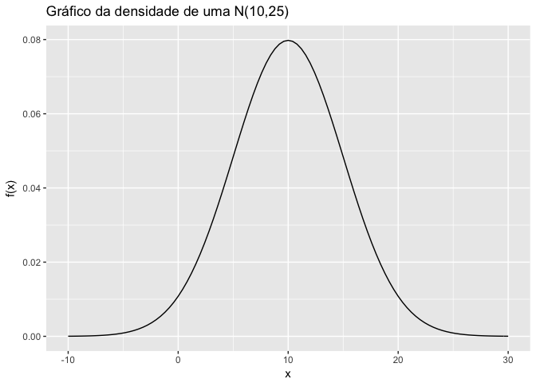

```r
library(ggplot2)
ggplot(data = data.frame(x = c(-10,30)), aes(x=x)) + stat_function(fun = dnorm, args = list(mean = 10, sd = 5)) + ylab("f(x)") + ggtitle("Gráfico da densidade de uma N(10,25)")
```

Plotando a função de distribuição acumulada de uma distribuição normal.

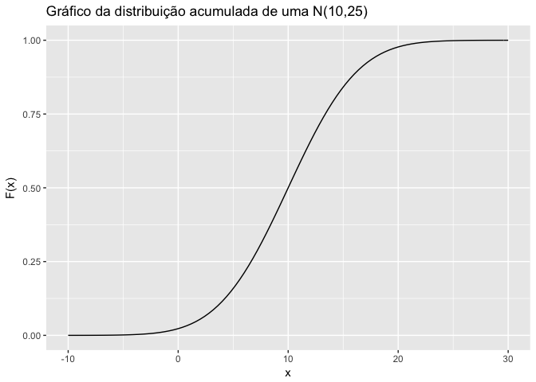

```r
ggplot(data = data.frame(x = c(-10,30)), aes(x=x)) + stat_function(fun = pnorm, args = list(mean = 10, sd = 5)) + ylab("F(x)") + ggtitle("Gráfico da distribuição acumulada de uma N(10,25)")
```

Gerando uma amostra aleatória de uma $N(10,25)$ e checando se a amostra tem um formato semelhante com a distribuição utilizada para gerar os dados.

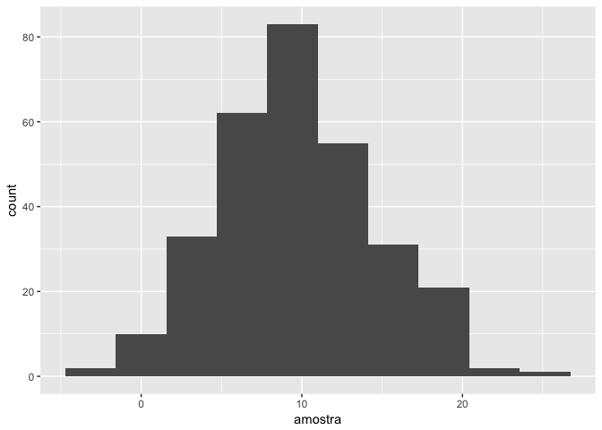

```r
base = data.frame(amostra = rnorm(300,10,5))

#Fazendo o histograma da amosytra gerada acima
ggplot(data = base, aes(x = amostra)) + geom_histogram(bins = 10)
```

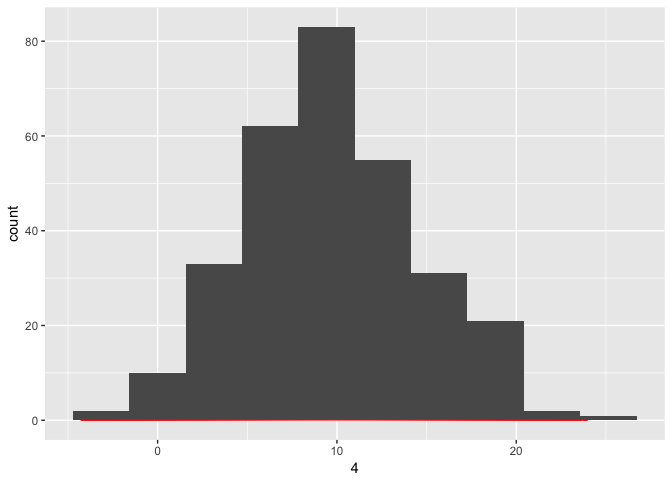

```r
#Comparando o histograma com a curva da distribuição teórica que gerou os dados: PROBLEMA????
ggplot(data = base, aes(x = amostra)) + geom_histogram( bins = 10) + stat_function(fun = dnorm, args = list(mean = 10, sd = 5), col = "red") + xlab(x)
```

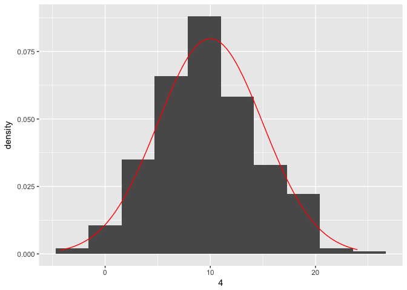

```r
#Corrigindo o problema do gráfico acima
ggplot(data = base, aes(x = amostra)) + geom_histogram(aes(y = ..density..), bins = 10) + stat_function(fun = dnorm, args = list(mean = 10, sd = 5), col = "red") + xlab(x)
```

Juntando os gráficos em uma única figura:

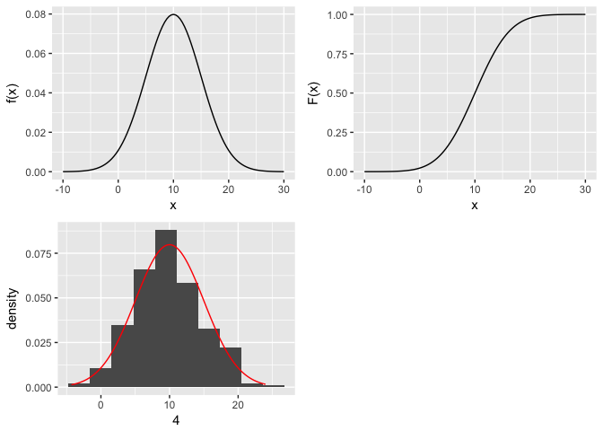

```r
library(gridExtra)

#Gráfico da densidade de X
graf1 = ggplot(data = data.frame(x = c(-10,30)), aes(x=x)) + stat_function(fun = dnorm, args = list(mean = 10, sd = 5)) + ylab("f(x)")

#Gráfico de F(x)
graf2 = ggplot(data = data.frame(x = c(-10,30)), aes(x=x)) + stat_function(fun = pnorm, args = list(mean = 10, sd = 5)) + ylab("F(x)")

#Histograma da amostra
graf3 = ggplot(data = base, aes(x = amostra)) + geom_histogram(aes(y = ..density..), bins = 10) + stat_function(fun = dnorm, args = list(mean = 10, sd = 5), col = "red") + xlab(x)

grid.arrange(graf1,graf2,graf3, ncol = 2)
```

Outras distribuições:

- dexp - densidade da exponencial;
- rchisq - sorteia uma amostra da distribuição qui-quadrado;
- qt - calcula o quantil de uma t-student;
- pf - calcula $F(x)$ de uma $F$;
- rbeta - sorteia uma amostra da distribuição beta;
- dunif - densidade de uma uniforme (contínua);
- E a uniforme discreta???